# SIMULATION

Brownian motion can be thought of as the motion of a particle that diffuses randomly along a line. At each point $t$, the particle’s position $B_t$ is normally distributed about the line with variance t, i.e., $B_t \sim N(0, t)$. As $t$ increases, the particle’s position is more diffuse.

Geometric Brownian Motion (GBM) and Arithmetic Brownian Motion (ABM) are two common types of stochastic processes used in finance to simulate the fluctuations of stock prices or other financial assets.

# 1 Simulation the stock price

## 1.1 Geometric Brownian Motion

### 1.1.1 Concept

A stochastic process $(S_t)_{t\geq0}$ is a geometric Brownian motion if it satisfies the stochastic differential equation: $dS_t = \mu S_t dt + \sigma S_t dW_t$.

Where $W_t$ is a standard Brownian motion with respect to $P, \mu, \sigma$ are constant drift and volatility.

### 1.1.2 Simulating Geometric Brownian motion

A Geometric Brownian motion $(S_t)_{0 \leq t \leq \infty}$ has a differential form $dS_t = S_t(\mu dt + \sigma dW_t)$. Solving this, we have $S_t = S_0 \exp[(\mu - \frac{1}{2}\sigma^2)t+\sigma W_t]$.

Proof: Applying Ito Formula
$$\begin{align*}
d\ln(S_t) &= df(S_t,t) = \frac{1}{S_t}dS_t - \frac{1}{2 S_t^2}dS_t^2 = \frac{1}{S_t}S_t(\mu dt + \sigma dW_t) - \frac{1}{2 S_t^2}(S_t^2 \sigma^2 dt) \\
&= \mu dt + \sigma dW_t - \frac{1}{2}\sigma^2 dt = (\mu - \frac{1}{2}\sigma^2)dt + \sigma dW_t.\\
&\implies \int_{0}^t dln(S_u) = \int_{0}^t(\mu - \frac{1}{2}\sigma^2)dt + \int_{0}^t\sigma dW_t
\end{align*}$$

$$\implies ln(S_t) -ln(S_0) = (\mu - \frac{1}{2}\sigma^2)(t-0) + \sigma (W_t-W_0) \implies S_t = S_0 \exp \bigg[(\mu - \frac{1}{2}\sigma^2)t+\sigma W_t \bigg]$$

Suppose we want to model a geometric Brownian motion in a time interval $[0,T]$

- Divide the interval: $0 = t_0 < t_1 < ... < t_n = T_n$, with the time step $h = t_i - t_{i-1}$.
- Following the model, we have:
  $$S_{t_i} = S_0 \exp{\bigg[(\mu -\frac{1}{2}\sigma^2)t_i+ \sigma W_{t_i}\bigg]}\\
  S_{t_{i-1}} = S_0 \exp{\bigg[(\mu -\frac{1}{2}\sigma^2)t_{t_{i-1}}+ \sigma W_{t_{i-1}}\bigg]}$$
- The value of $S_{t_{i-1}}$ is determined by a recursive formula:
  $$S_{t_i} = S_{t_{i-1}} \exp{\bigg[(\mu -\frac{1}{2}\sigma^2)(t_i-t_{i-1})+ \sigma (W_{t_i}- W_{t_{i-1}})\bigg]}
  = S_{t_{i-1}} \exp{\bigg[(\mu - \frac{1}{2}\sigma^2)h+ \sigma \sqrt{h}*X\bigg]}$$

Where $X \sim N(0,1)$.

### 1.1.3 Example

Simulate the following GBM $dS_t=S_t(0.1dt+0.4dW_t)$ on the interval $[0,1]$ with step size $1/1000$.

Firsly, one path

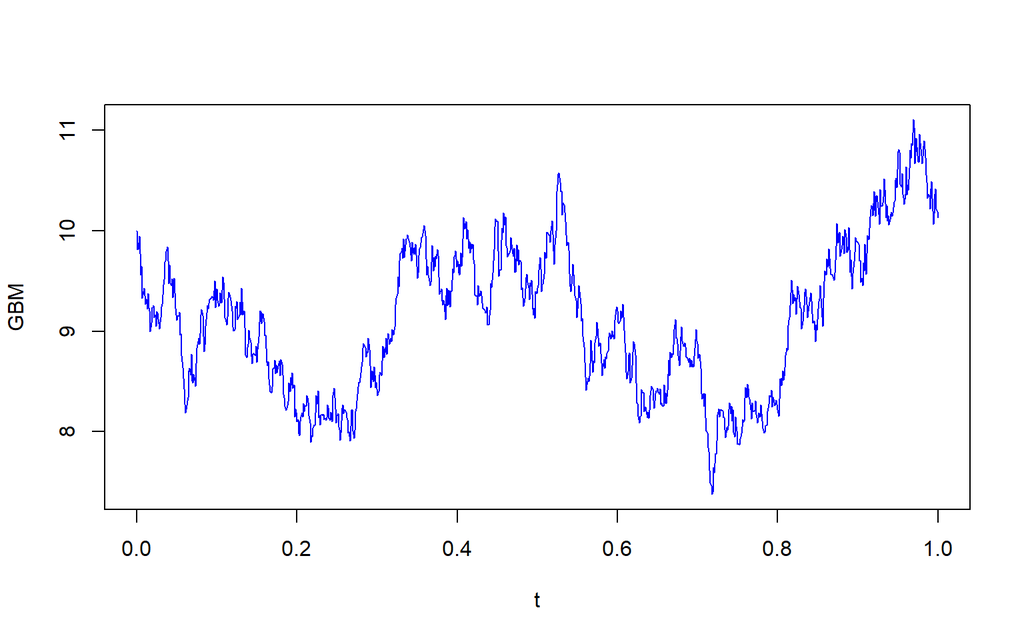

```r
GBM = function(S0, mu, sigma, T, N){
  # T = 1 (expiry time)
  # N = 1000 (number of simulation points)

  h = T/N  #(the timestep of the simulation)
  X = cumprod(c(S0, exp((mu - 1/2 * sigma^2)*h + sigma*sqrt(h)*rnorm(N, mean=0, sd=1))))
  return(X)
}
h = 1/1000
t = seq(0 , 1 , by = h)
plot(t, GBM(S0=10, mu = 0.1, sigma = 0.4, T = 1, N = 1000), type ="l", col = "blue", xlab = 't', ylab= 'GBM')
```

Secondly, 100 paths

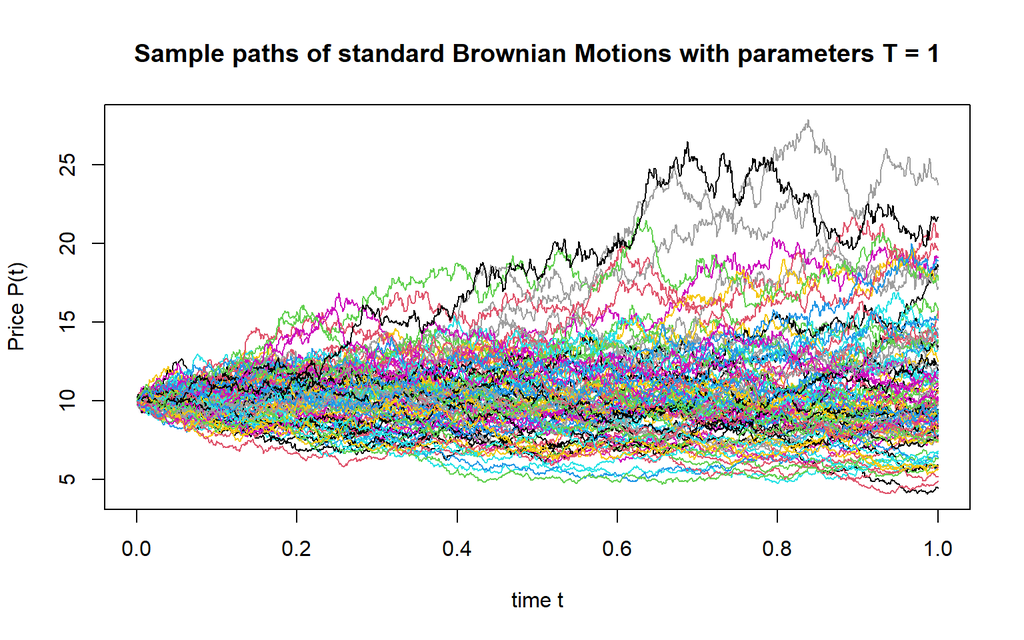

```r
T = 1
N = 1000
M = 100

X = replicate(M, GBM(S0=10, mu = 0.1, sigma = 0.4, T = T, N = N))
t = seq(0, T, by = T/N)

ymax=max(X); ymin = min(X) #bounds for simulated prices
plot(t, X[,1], t = 'l', main = 'Sample paths of standard Brownian Motions with parameters T = 1', ylim = c(ymin, ymax), col = 1, ylab = "Price P(t)", xlab  = "time t")

for (i in 2:M){lines(t, X[,i], t= 'l', ylim = c(ymin, ymax), col = i)}
```

### 1.1.4 Applications to model real stock prices

Calibration parameters of geometric Brownian motion for VIC share prices. Consider the data of prices of VIC from 31-12-2014 to 2022-11-30. Let $S_t$ be the price of VIC share at time $t$ and suppose $S_t$ is governed by the geometric Brownian motion:

$$\begin{align*}
dS_t = \mu S_t dt + \sigma S_t dW_t
\end{align*}$$

where $W_t$ is a standard Brownian Motion under the physical world $(\Omega, F, (F_t)_{t \geq 0}, P)$.

#### 1.1.4.1 Step 1: Manipulate the data

```r
df <- read.csv(file="C:\\Users\\ASUS\\Downloads\\VIC Historical Data.csv", head = T, stringsAsFactors = F)
names(df)[1] = "Date"
df$Date <- as.Date(as.character(df$Date), format="%m/%d/%Y")
df$Price=as.numeric(gsub(",","",df$Price))
df = df[,1:2]
df <- df[order(df$Date),]
df <- subset(df, df$Date >= "2014-12-31" & df$Date <= "2022-11-30")
```

#### 1.1.4.2 Step 2: Visualize the data

```r
df %>%
    ggplot(aes(x = Date, y =Price)) +
    geom_line(size = 1,col="blue") +
    labs(title = "Daily Stock Prices",
         x = "", y = "Closed Prices", color = "") +
    scale_y_continuous() +
    theme_tq() +
    scale_color_tq()
```

[output not shown]

#### 1.1.4.3 Step 3: Convert data into time series

```r
df <- xts(as.numeric(df[,2]),order.by = df[,1])
X<-df[,1]
```

#### 1.1.4.4 Step 4: Estimate parameters using quasi maximum likelihood

Using the quasi-maximum likelihood estimation to estimate parameters: use packages “yuima”.

```r
Delta <- 1/252
gBm <- setModel(drift="mu*x", diffusion="sigma*x")
mod <- setYuima(model=gBm, data=setData(X, delta=Delta))
fit <- qmle(mod, start=list(mu=0.01, sigma=0.01),
lower=list(mu=0, sigma=0),
upper=list(mu=100, sigma=100))
summary(fit)
```

```
## Quasi-Maximum likelihood estimation
##
## Call:
## qmle(yuima = mod, start = list(mu = 0.01, sigma = 0.01), lower = list(mu = 0,
##     sigma = 0), upper = list(mu = 100, sigma = 100))
##
## Coefficients:
##        Estimate  Std. Error
## sigma 0.2898966 0.004611625
## mu    0.1587721 0.103526121
##
## -2 log L: 33488.05
```

The obtained parameters are $\mu = 0.1587721$ and $\sigma = 0.2898966$. The governed SDE is thus $dS_t=0.1587721S_tdt+0.2898966S_tdW_t$, where $t$ is measured in years. We now need to simulate the geometric Brownian motion.

**What is the distribution of predicted VIC price in the next 7 trading days based on the parameters found on above.**

The model for VIC is $dS_t=0.1587721S_tdt+0.2898966S_tdW_t$. The VIC stock price on 30/11/22 is 69600. From 30/11/22 to 09/12/2022, there are 7 trading days. We use simulation to estimate the stock price on 09/12/2022.

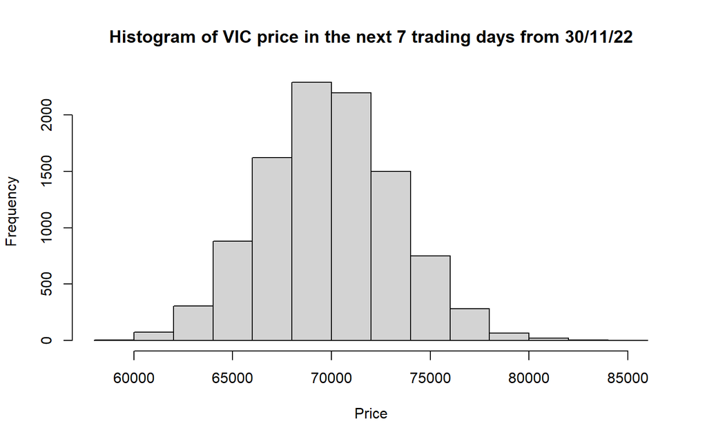

```r
T=7/252
N=1000
M=10000
S=replicate(M, GBM(S0=as.numeric(X[length(X)]),mu=coef(summary(fit))[2,1], sigma=coef(summary(fit))[1,1],T=T, N=N))

hist(S[N,],xlab="Price", main="Histogram of VIC price in the next 7 trading days from 30/11/22")
```

**Forecast about future movements of VIC price in 1 year from 30/11/22.**

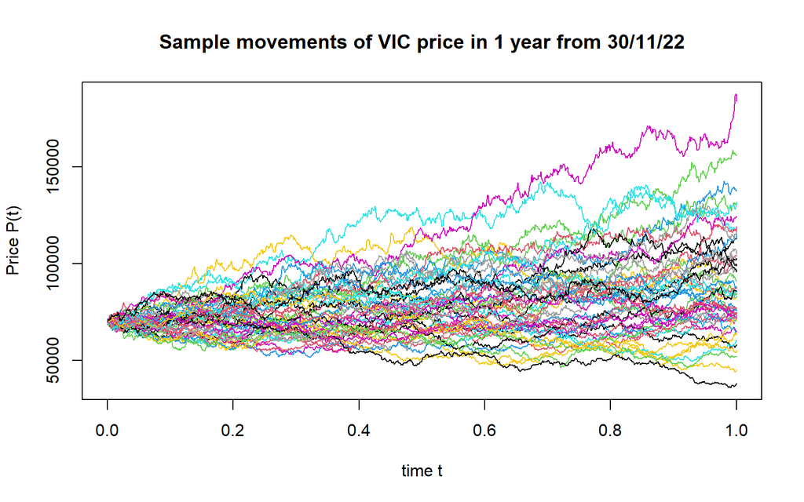

```r
T=1
N=1000
M=50
S=replicate(M, GBM(S0=as.numeric(X[length(X)]),mu=coef(summary(fit))[2,1], sigma=coef(summary(fit))[1,1],T=T, N=N))

t=seq(0,T,by=T/N)

ymax=max(S); ymin=min(S) #bounds for simulated prices
plot(t,S[,1],t='l',main='Sample movements of VIC price in 1 year from 30/11/22',ylim=c(ymin, ymax), col=1,
ylab="Price P(t)",xlab="time t")
for(i in 2:M){lines(t,S[,i], t='l',ylim=c(ymin, ymax),col=i)}
```

## 1.2 Arithmetic Brownian Motion

### 1.2.1 Concept

A stochastic process $(S_t)_{t \geq 0}$ is called an arithmetic Brownian motion on the filtered probability space $(\Omega, F, (F_t)_{t \geq 0}, P)$ if it satisfies the stochastic differential $dS_t = \mu dt + \sigma dW_t$ where

$W_t$ is a standard Brownian motion with respect to $P, \mu, \sigma$ are constant and $W_t \sim N(0,t)$.

### 1.2.2 Simulating Arithmetic Brownian motion

An arithmetic Brownian motion $(S_t)_{0 \leq t < \infty}$ has a differential form $dS_t = \mu dt + \sigma dW_t$.

Proof: Applying Ito formula
$$\begin{align*}
dS_t = \mu dt + \sigma dW_t &\implies \int_0^T dS_t = \int_0^T \mu dt+\int_0^T \sigma dW_t \\ &\implies S_T -S_0 = \mu (T-0) + \sigma (W_T - W_0) \\ &\implies S_T = S_0 + \mu T + \sigma(W_T - W_0)
\end{align*}$$

Suppose we want to model an arithmetic Brownian motion in a time interval $[0,T]$.

- Divide the interval: $0 = t_0 < t_1 < t_2 < ... < t_n = T$ with the time step $h=t_i - t_{i-1}$.
- Following the model, we have:
  $$S_{t_i} = S_0 + \mu t_i + \sigma W_{t_i}$$
  and
  $$S_{t_{i-1}} = S_0 + \mu t_{i-1} + \sigma W_{t_{i-1}}$$
  .
- The value of $S_{t_i}$ is determined by a recursive formula:
  $$\begin{align*} S_{t_i} &= S_{t_{i-1}} + \mu \cdot (t_i - t_{i-1}) + \sigma \cdot (W_{t_i} - W_{t_{i-1}}) \\ &= S_{t_{i-1}} + \mu \cdot h + \sigma \cdot \sqrt{h} \cdot X \end{align*}$$
  Where $X \sim N(0,1)$

### 1.2.3 Example

Simulate the following ABM $dS_t=5dt+3dW_t$ on the interval $[0,1]$ with step size $1/1000$.

Firsly, one path

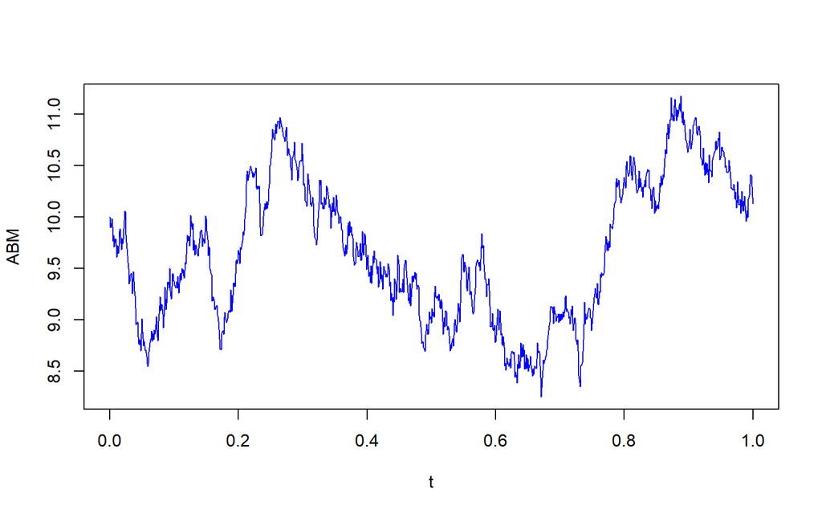

```r
ABM=function(S0,mu, sigma,T,N) {
# T=1  expiry time
# N=100  number of simulation points

h=T/N  # the timestep of the simulation
X=cumsum(c(S0, mu*h+sigma*sqrt(h)*rnorm(N,mean=0, sd=1) ))
return(X)
}
h=1/1000
t=seq(0,1,by=h)
plot(t,ABM(S0=10,mu= 5, sigma=3,1,N=1000), type="l", col="blue",xlab="t",ylab="ABM")
```

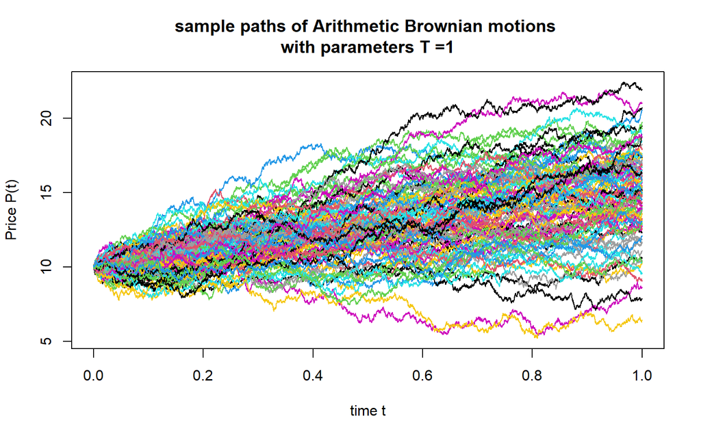

```r
T=1
N=10000
M=100
X=replicate(M, ABM(S0=10,mu=5, sigma=3,T=T, N=N))

t=seq(0,T,by=T/N)

ymax=max(X); ymin=min(X) #bounds for simulated prices
plot(t,X[,1],t='l',main='sample paths of Arithmetic Brownian motions
with parameters T =1',ylim=c(ymin, ymax), col=1,
ylab="Price P(t)",xlab="time t")
for(i in 2:M){lines(t,X[,i], t='l',ylim=c(ymin, ymax),col=i)}
```

### 1.2.4 Applications to model real stock prices

#### 1.2.4.1 Step 1: Manipulate the data

```r
df <- read.csv(file="C:\\Users\\ASUS\\Downloads\\VIC Historical Data.csv", head = T, stringsAsFactors = F)
names(df)[1] = "Date"
df$Date <- as.Date(as.character(df$Date), format="%m/%d/%Y")
df$Price=as.numeric(gsub(",","",df$Price))
df = df[,1:2]
df <- df[order(df$Date),]
df <- subset(df, df$Date >= "2014-12-31" & df$Date <= "2022-11-30")
```

#### 1.2.4.2 Step 2: Visualize the data

```r
df %>%
    ggplot(aes(x = Date, y =Price)) +
    geom_line(size = 1,col="blue") +
    labs(title = "Daily Stock Prices",
         x = "", y = "Closed Prices", color = "") +
    scale_y_continuous() +
    theme_tq() +
    scale_color_tq()
```

[output not shown]

#### 1.2.4.3 Step 3: Convert data into time series

```r
df <- xts(as.numeric(df[,2]),order.by = df[,1])
X<-df[,1]
```

#### 1.2.4.4 Step 4: Estimate parameters using quasi maximum likelihood

```r
Delta <- 1/252
gBm <- setModel(drift="mu", diffusion="sigma")
mod <- setYuima(model=gBm, data=setData(X, delta=Delta))
fit <- qmle(mod, start=list(mu=0.01, sigma=0.01),
lower=list(mu=0, sigma=0),
upper=list(mu=1000000, sigma=1000000))
summary(fit)
```

```
## Quasi-Maximum likelihood estimation
##
## Call:
## qmle(yuima = mod, start = list(mu = 0.01, sigma = 0.01), lower = list(mu = 0,
##     sigma = 0), upper = list(mu = 1e+06, sigma = 1e+06))
##
## Coefficients:
##        Estimate Std. Error
## sigma 22660.147   366.1786
## mu     5319.833   957.2145
##
## -2 log L: 34313.15
```

**What is the distribution of predicted VIC price in the next 7 trading days based on the parameters found on above.**

The model for VIC is $dS_t=5319.833dt+22660.147dW_t$. The VIC stock price on 30/11/22 is 69600

From 30/11/22 to 09/12/2022, there are 7 trading days. We use simulation to estimate the stock price on 09/12/2022.

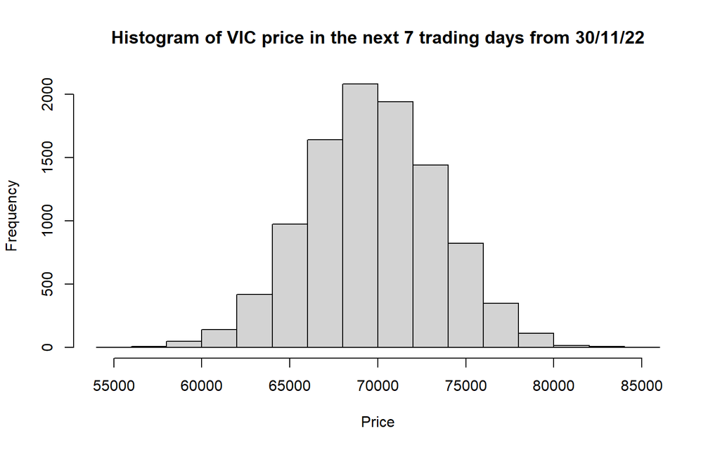

```r
T=7/252
N=1000
M=10000
S=replicate(M, ABM(S0=as.numeric(X[length(X)]),mu=coef(summary(fit))[2,1], sigma=coef(summary(fit))[1,1],T=T, N=N))

hist(S[N,],xlab="Price", main="Histogram of VIC price in the next 7 trading days from 30/11/22")
```

**Forecast about future movements of VIC price in 1 year from 30/11/22.**

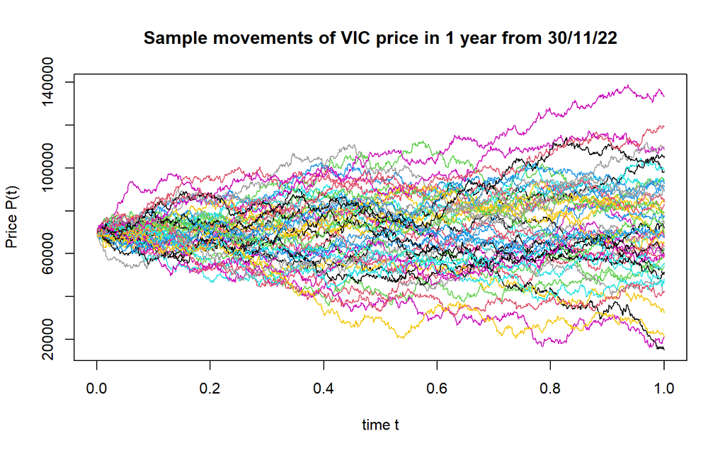

```r
T=1
N=1000
M=50
S=replicate(M, ABM(S0=as.numeric(X[length(X)]),mu=coef(summary(fit))[2,1], sigma=coef(summary(fit))[1,1],T=T, N=N))

t=seq(0,T,by=T/N)

ymax=max(S); ymin=min(S) #bounds for simulated prices
plot(t,S[,1],t='l',main='Sample movements of VIC price in 1 year from 30/11/22',ylim=c(ymin, ymax), col=1,
ylab="Price P(t)",xlab="time t")
for(i in 2:M){lines(t,S[,i], t='l',ylim=c(ymin, ymax),col=i)}
```

# 2 Simulation the return

## 2.1 Monte Carlo Simulations by GBM

The technique is often used in econometrics when the properties of a particular estimation method are not known.

Monte Carlo method is useful method for simulate the stock’s returns. Consider a stock with $S_t$ the price at time $t$. The dynamic of price is modeled by SDE.
$$dS_t = \mu S_t dt + \sigma S_t dB_t$$

Let $Y_t = \log{(\frac{S_t}{S_{t-1}})} = \log{(S_t)} - \log(S_{t-1})$ (the log return). We have:
$$S_t = S_0 e^{(\mu - \frac{\sigma^2}{2})t + \sigma B_t}$$

Hence, $\log(S_t) = \log(S_0) + (\mu - \frac{\sigma^2}{2})t + \sigma B_t$

And, $\log(S_{t-1}) = \log(S_0) + (\mu - \frac{\sigma^2}{2})(t-1) + \sigma B_{t-1}$

So, we have:
$$Y_t = \log{\biggl(\frac{S_t}{S_{t-1}} \biggl)} = \biggl(\mu - \frac{\sigma^2}{2}\biggl) + \sigma(B_t - B_{t-1})$$

Put $Z_{t,t-1} = \sigma (B_t-B_{t-1})$. Then $Z \sim N(0, \sigma^2)$. Note that $\mu$ and $\sigma$ are mean and volatility of the stock. We have:
$$Y_t = \biggl(\mu - \frac{\sigma^2}{2} \biggl) + Z \sim N(\mu - \frac{\sigma^2}{2}, \sigma^2)$$

### 2.1.1 Step 1: Manipulate the data

```r
df <- read.csv(file="C:\\Users\\ASUS\\Downloads\\VIC Historical Data.csv", head = T, stringsAsFactors = F)
names(df)[1] = "Date"
df$Date <- as.Date(as.character(df$Date), format="%m/%d/%Y")
df$Price=as.numeric(gsub(",","",df$Price))
df = df[,1:2]
df <- df[order(df$Date),]
df <- subset(df, df$Date >= "2014-12-31" & df$Date <= "2022-11-30")
```

### 2.1.2 Step 2: Visualize the data

```r
df %>%
    ggplot(aes(x = Date, y =Price)) +
    geom_line(size = 1,col="blue") +
    labs(title = "Daily Stock Prices",
         x = "", y = "Closed Prices", color = "") +
    scale_y_continuous() +
    theme_tq() +
    scale_color_tq()
```

[output not shown]

### 2.1.3 Step 3: Convert data into time series

```r
df <- xts(as.numeric(df[,2]),order.by = df[,1])
X<-df[,1]
```

### 2.1.4 Step 4: Estimate parameters using quasi maximum likelihood

Using the quasi-maximum likelihood estimation to estimate parameters: use packages “yuima”.

```r
Delta <- 1/252
gBm <- setModel(drift="mu*x", diffusion="sigma*x")
mod <- setYuima(model=gBm, data=setData(X, delta=Delta))
fit <- qmle(mod, start=list(mu=0.01, sigma=0.01),
lower=list(mu=0, sigma=0),
upper=list(mu=100, sigma=100))
summary(fit)
```

```
## Quasi-Maximum likelihood estimation
##
## Call:
## qmle(yuima = mod, start = list(mu = 0.01, sigma = 0.01), lower = list(mu = 0,
##     sigma = 0), upper = list(mu = 100, sigma = 100))
##
## Coefficients:
##        Estimate  Std. Error
## sigma 0.2898966 0.004611625
## mu    0.1587721 0.103526121
##
## -2 log L: 33488.05
```

The obtained parameters are $\mu = 0.1587721$ and $\sigma = 0.2898966$. The governed SDE is thus $dS_t=0.1587721S_tdt+0.2898966S_tdW_t$, where $t$ is measured in years. We now need to simulate the geometric Brownian motion.

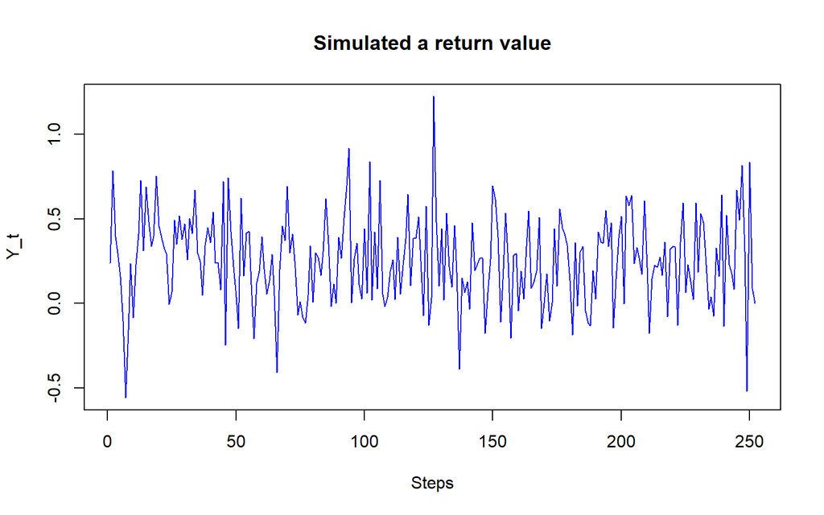

```r
mu <- coef(summary(fit))[2,1]
sigma <- coef(summary(fit))[1,1]
steps <- 252

Y_t <- (mu - sigma^2/2 ) + rnorm(steps, mean = mu - (sigma^2)/2, sd = sigma)

plot(Y_t, type = "l", xlab = "Steps", ylab = "Y_t", main = "Simulated a return value", col = 'blue')
```

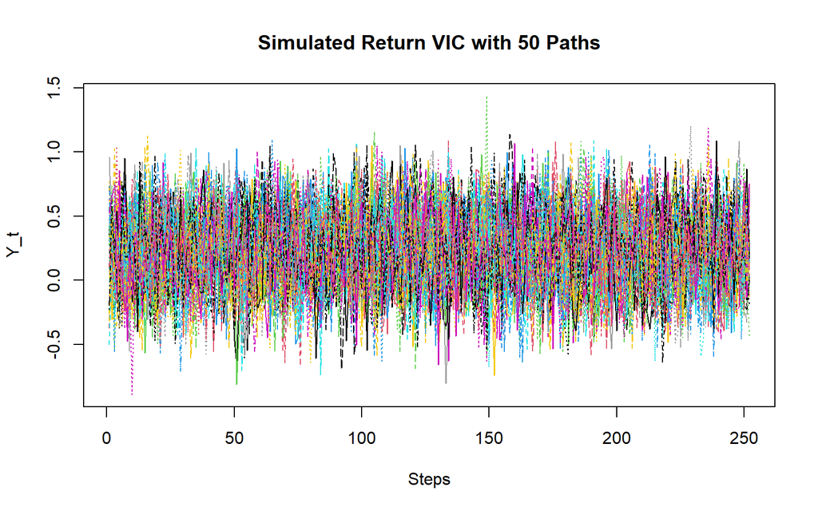

```r
paths <- 50

Y_t <- matrix((mu - sigma^2/2 ) + rnorm(steps * paths, mean = mu - (sigma^2)/2, sd = sigma), nrow = steps, ncol = paths)

matplot(Y_t, type = "l", col = 1:paths, xlab = "Steps", ylab = "Y_t", main = "Simulated Return VIC with 50 Paths")
```